# A06

Claire

2025-05-11

# **AS06. Gender Data Visualization**

## 第一張圖：2022年各縣市祭祀公業派下員女性比例

```r
library(sf)
library(tmap)
library(dplyr)
```

```
## ── tmap v3 code detected ───────────────────────────────────────────────────────
```

[output not shown]

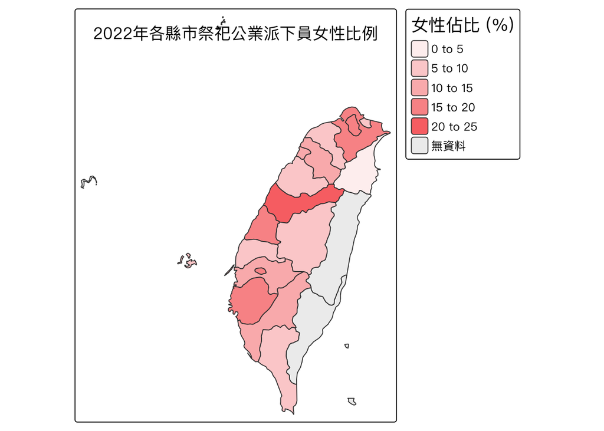

```r
library(readr)
library(readODS)

# 1. 讀取地圖
map <- st_read("data/tw-counties.geojson.json")  # 檔名請確認無誤
# 2. 讀入 ODS 檔（第1工作表 = 2022年），跳過前3列
data <- read_ods("data/祭祀公業法人派下員統計.ods", sheet = 1, skip = 3)
# 2-1確實重新命名欄位
colnames(data) <- c("name", "法人數", "總人數", "男性", "女性", "女性比率")

# 2-2移除總計列
data <- subset(data, name != "小計")

# 3. 合併地圖與資料
map_data <- left_join(map, data, by = "name")
# 4. 畫地圖
library(RColorBrewer)

# 建立你想要的粉紫橘色階（這裡用類似色系，如 "PuOr"，或你可以自定義顏色）
# 或用手動方式列出 hex 色碼（依照你截圖上的配色）

my_palette <- c("#fef1f1", "#fdd5d5", "#fcc7c7", "#fbabab", "#fa8f8f", "#f97474")

tm_shape(map_data) +
  tm_polygons(
    col = "女性比率",
    palette = my_palette,
    title = "女性佔比 (%)",
    textNA = "無資料",       # 將 Missing 改為「無資料」
    colorNA = "#eeeeee"    # 無資料區域顏色（可自訂）
  ) +
   tm_layout(
  title = "2022年各縣市祭祀公業派下員女性比例",
  title.fontface = "bold",
  title.size = 2.8,                  # ⬅️ 加粗字體用這個參數
  fontfamily = "PingFang TC",
  legend.title.size = 1.2,
  legend.text.size = 0.8
)
```

## 第二張圖：2018–2022各縣市祭祀公業派下員的女性比率變化

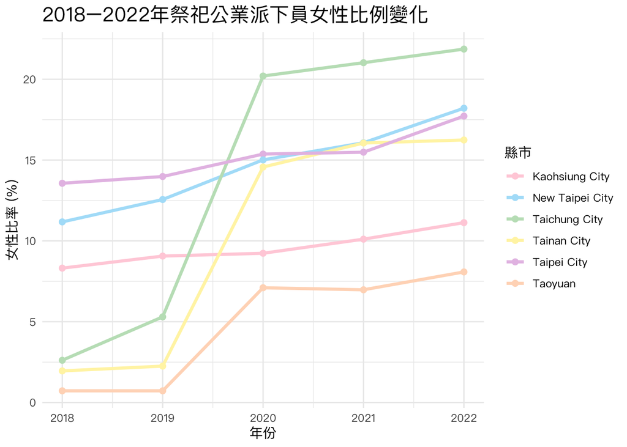

```r
library(readODS)
library(dplyr)
library(ggplot2)

# 年份與對應的 sheet 名
years <- c("107", "108", "109", "110", "111")
year_labels <- c(2018, 2019, 2020, 2021, 2022)

# 建立一個空的總表
all_data <- data.frame()

# 用迴圈讀取每一年
for (i in seq_along(years)) {
  sheet_name <- years[i]
  year <- year_labels[i]

  df <- read_ods("data/祭祀公業法人派下員統計.ods", sheet = sheet_name, skip = 3)
  colnames(df) <- c("name", "法人數", "總人數", "男性", "女性", "女性比率")
  df <- df[df$name != "小計", ]
  df$year <- year
  all_data <- rbind(all_data, df)
}
# 選擇要畫的縣市（你可自由調整）
selected_cities <- c("Taipei City", "New Taipei City", "Taichung City", "Tainan City", "Kaohsiung City","Taoyuan")

# 過濾資料
plot_data <- all_data %>% filter(name %in% selected_cities)

# 畫折線圖
macaron_colors <- c(
  "#FFD1DC",  # 馬卡龍粉
  "#AEE1F9",  # 馬卡龍藍
  "#C1E1C1",  # 馬卡龍綠
  "#FFF4B2",  # 馬卡龍黃
  "#E6C1E6",  # 馬卡龍紫
  "#FFDAC1"   # 馬卡龍橘粉
)
ggplot(plot_data, aes(x = year, y = `女性比率`, color = name)) +
  geom_line(size = 1.2) +
  geom_point(size = 2) +
    scale_color_manual(values = macaron_colors) +
  labs(
    title = "2018–2022年祭祀公業派下員女性比例變化",
    x = "年份", y = "女性比率 (%)", color = "縣市"
  ) +
  theme_minimal(base_family = "PingFang TC") +
  theme(
    plot.title = element_text(size = 16, face = "bold"),
    legend.position = "right"
  )
```

## 第三張圖：2018–2022各縣市祭祀公業派下員的女性比率變化（看各縣市個別趨勢）

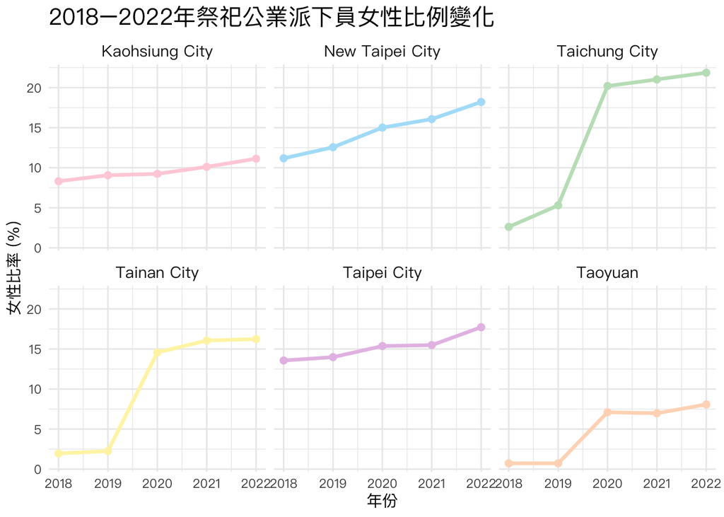

```r
library(readODS)
library(dplyr)
library(ggplot2)

# 年份與對應的 sheet 名
years <- c("107", "108", "109", "110", "111")
year_labels <- c(2018, 2019, 2020, 2021, 2022)

# 建立一個空的總表
all_data <- data.frame()

# 用迴圈讀取每一年
for (i in seq_along(years)) {
  sheet_name <- years[i]
  year <- year_labels[i]

  df <- read_ods("data/祭祀公業法人派下員統計.ods", sheet = sheet_name, skip = 3)
  colnames(df) <- c("name", "法人數", "總人數", "男性", "女性", "女性比率")
  df <- df[df$name != "小計", ]
  df$year <- year
  all_data <- rbind(all_data, df)
}
# 選擇要畫的縣市（你可自由調整）
selected_cities <- c("Taipei City", "New Taipei City", "Taichung City", "Tainan City", "Kaohsiung City","Taoyuan")

# 過濾資料
plot_data <- all_data %>% filter(name %in% selected_cities)

# 畫折線圖
macaron_colors <- c(
  "#FFD1DC",  # 馬卡龍粉
  "#AEE1F9",  # 馬卡龍藍
  "#C1E1C1",  # 馬卡龍綠
  "#FFF4B2",  # 馬卡龍黃
  "#E6C1E6",  # 馬卡龍紫
  "#FFDAC1"   # 馬卡龍橘粉
)
ggplot(plot_data, aes(x = year, y = `女性比率`, color = name)) +
  geom_line(size = 1.2) +
  geom_point(size = 2) +
  scale_color_manual(values = macaron_colors) +
  facet_wrap(~ name) +
  labs(
    title = "2018–2022年祭祀公業派下員女性比例變化",
    x = "年份", y = "女性比率 (%)", color = "縣市"
  ) +
  theme_minimal(base_family = "PingFang TC") +
  theme(
    plot.title = element_text(size = 16, face = "bold"),
    strip.text = element_text(face = "bold", size = 11),
    legend.position = "none"
  )
```

## **解釋：**

資料新聞標題：祭祀公業台中女性比例全台最高，資料看性別差距逐年變化

詮釋欄位：

- **name**：祭祀公業法人派下員統計
- **資料範圍**：2018–2022
- **href**：https://www.gender.ey.gov.tw/gecdb/Stat_Statistics_DetailData.aspx?sn=BFvp18cp2BsfqmG8OxvDBw%40%40&d=194q2o4!otzoYO!8OAMYew%40%40
- **def**：統計全國祭祀公業法人數量，按縣市、性別與年份區分
- **cat1**：縣市
- **cat2**：性別
- **複分類**：年度（2018–2022）、縣市別女性派下員佔比（%）

另外，2021 年之前此項統計由內政部民政司負責，2022 年起轉由宗教及禮制司接手，政府開始重視宗教作為專業政策領域。